# Effect of the Loan Characteristics on the Loan Rate and Outcome

## by Agugua Urenna Onome

## Investigation Overview

In this investigation, I wanted to look at the characteristics of loans that could be used to predict their overall outcome (Default or Complete Loan Status). The main focus was on the following features: Borrower's Rate, Term, Income range, Debt to income ratio, Stated Monthly Income and Original Loan Amount as these are likely to have a strong impact on the outcome of the loan and on the rate on the loan

## Dataset Overview

The data consists of attributes of 113,937 loans including details on the loan such as loan amount, loan origination date, estimated returns, borrower rate (or interest rate), current loan status, loan rating; Details on the borrower such as borrowers' occupation, borrowers' income, employment status and many others. About 63 variables were filtered out as they were not relevant to the analysis.

## Distribution of Loan Amount

The loan amount has a wide range of values. Plotted on a logarithmic scale because the distribution was skewed to the right. the distribution has peaks between 3k and 5k and large spikes are also noticed at 10k, 15k, 20k and 25k.

he most value for the loan amount is between 3k and 5k and there are large spikes at 10k, 15k, 20k and 20k

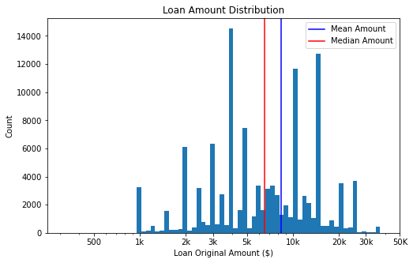

## Distribution of the Loan Term

From the dataset, most of the loans taken out have a 36 months term with very little loans under the 12 months term

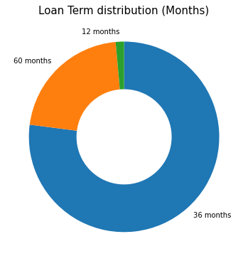

## Distribution of the Loan Status

Most loans of the are current loans are current loans. For loans that are not current, the completed loans take up a larger amount.

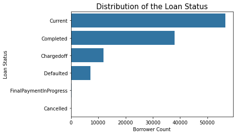

## Loans by Income Range and Home Ownership

Borrowers with incomes ranging from ($)50,000-100,000+ are mostly homeowners with income earners between 25,000 - 49, 999 taking out the most loans.

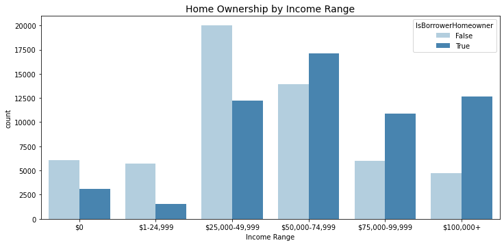

## Loans by Employment Status and Term

Employed borrowers with full time employment take loans with 36months term. Only a small number of employed borrowers took loans with a 12 months term.

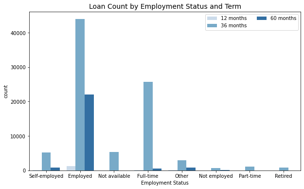

## Loan Status vs Term

From the figure, there's some variation in the default percentage. Loans under the 12months term had defaults 6.66% of the time, loans of 36 months term had defaults 33.45% of the time while loans under the 60 months term had defaults 45.13% of the time.

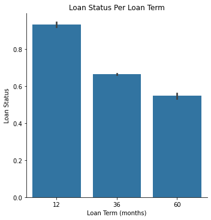

## Loan Status vs Rating

From the figure, there's some variation in the default percentage.

- Loans with the HR rating had defaults 42.97% of the time,
- Loans with E rating had defaults 40.85% of the time,
- Loans with the D rating had defaults 34.03% of the time
- Loans with the C rating had defaults 31.47% of the time
- Loans with the B rating had defaults 24.53% of the time
- Loans with the A rating had defaults 15.62% of the time
- Loans with the AA rating had defaults 6.64% of the time

We can safely say that the higher the rating, the less likely there is to be defaults

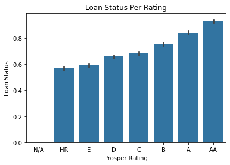

## Borrower Rate for each Term

We notice that the longer the term, the higher the rate. The 36months term which has the most borrower count has a median rate of about 20%

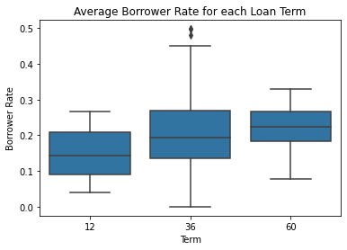

## Loan Count by Year

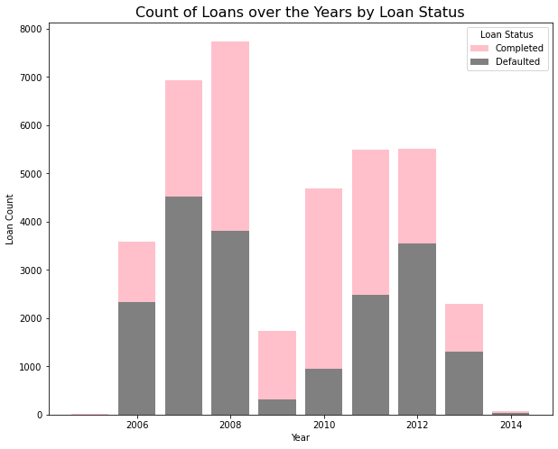

## Loan Status vs Rating by Term

The high risk loans are at a constant 36months term

[figure not shown]

## Income Range vs Loan Amount by loan Status

with the default class as 0 and the completed payments as 1, we can see that the more money people earn, the more money they borrow. Under the default class, the median loan amount between the 75,000 - 100,000+ is more than the completed loans

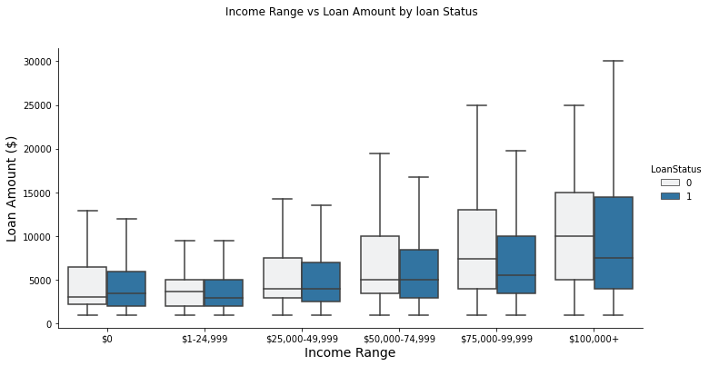

## The effect of the Loan Amount and interest rate on the loan status

We can see that the loan status/outcome is not dependent on the loan amount rather there is a weak negative correlation between the loan amount and the interest rate.

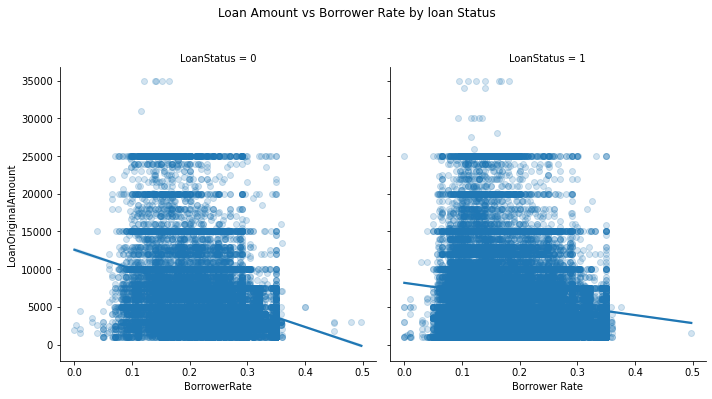

## Employment Status vs interest rate by the Loan status

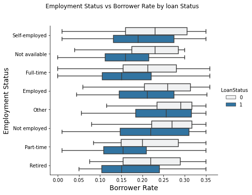